# IRF2BP2 CHIPS

```python
import os
from IPython.display import IFrame
import pandas as pd
import sys
sys.path.append('../..')
from JKBio.epigenetics import ChIP_helper as chip
from JKBio import Helper as helper
import igv
import numpy as np
import pyBigWig
import itertools
from sklearn.cluster import AgglomerativeClustering
from sklearn.mixture import GaussianMixture
from bokeh.plotting import *
from sklearn.manifold import MDS, TSNE
from sklearn.decomposition import PCA
from sklearn.preprocessing import scale
output_notebook()
%load_ext autoreload
%autoreload 2
```

```
The autoreload extension is already loaded. To reload it, use:
  %reload_ext autoreload
```

```python
bfolder = '../../data/recalib_bigwig_rep1/'
folder = '../../data/diffBinding_rep1/diffPeaks/'
```

```python
# Can we find a correlation between each MED1 replicate
```

```python
ls ../../data/diffBinding_rep1/diffPeaks/MV411_IRF2BP2_DMSO_MED1*
```

```
../../data/diffBinding_rep1/diffPeaks/MV411_IRF2BP2_DMSO_MED1_R1_vs_MV411_IRF2BP2_VHL_MED1_R1_c3.0_common.bed
../../data/diffBinding_rep1/diffPeaks/MV411_IRF2BP2_DMSO_MED1_R1_vs_MV411_IRF2BP2_VHL_MED1_R1_c3.0_cond1.bed
../../data/diffBinding_rep1/diffPeaks/MV411_IRF2BP2_DMSO_MED1_R1_vs_MV411_IRF2BP2_VHL_MED1_R1_c3.0_cond2.bed
```

```python
ls ../../data/diffBinding_rep2/diffPeaks/mp796*
```

```
../../data/diffBinding_rep2/diffPeaks/mp796_R1_vs_mp804_R1_c3.0_common.bed
../../data/diffBinding_rep2/diffPeaks/mp796_R1_vs_mp804_R1_c3.0_cond1.bed
../../data/diffBinding_rep2/diffPeaks/mp796_R1_vs_mp804_R1_c3.0_cond2.bed
```

```python
ls ../../data/IRF2BP2_degraded_3/diffPeaks/mp835*
```

```
../../data/IRF2BP2_degraded_3/diffPeaks/mp835-MV411_IRF2BP_DMSO_6h-MED1-r3_R1_vs_mp842-MV411_IRF2BP_VHL_6h-MED1-r3_R1_c3.0_common.bed
../../data/IRF2BP2_degraded_3/diffPeaks/mp835-MV411_IRF2BP_DMSO_6h-MED1-r3_R1_vs_mp842-MV411_IRF2BP_VHL_6h-MED1-r3_R1_c3.0_cond1.bed
../../data/IRF2BP2_degraded_3/diffPeaks/mp835-MV411_IRF2BP_DMSO_6h-MED1-r3_R1_vs_mp842-MV411_IRF2BP_VHL_6h-MED1-r3_R1_c3.0_cond2.bed
```

```python
diff1 = pd.DataFrame()
for val in os.popen('ls ../../data/diffBinding_rep1/diffPeaks/MV411_IRF2BP2_DMSO_MED1*').read().split('\n')[:-1]:
    a = pd.read_csv(val, sep='\t', header=0, names=['chr','start','end','name','val']).sort_values(by=['val'])
    diff1 = diff1.append(a).reset_index(drop=True)
```

```python
diff2 = pd.DataFrame()
for val in os.popen('ls ../../data/diffBinding_rep2/diffPeaks/mp796*').read().split('\n')[:-1]:
    a = pd.read_csv(val, sep='\t', header=0, names=['chr','start','end','name','val']).sort_values(by=['val'])
    diff2 = diff2.append(a).reset_index(drop=True)
```

```python
diff3 = pd.DataFrame()
for val in os.popen('ls ../../data/IRF2BP2_degraded_3/diffPeaks/mp835*').read().split('\n')[:-1]:
    a = pd.read_csv(val, sep='\t', header=0, names=['chr','start','end','name','val']).sort_values(by=['val'])
    diff3 = diff3.append(a).reset_index(drop=True)
```

```python
diff3['type'] = [val.split('_')[-2] for val in diff3.name.tolist()]
diff2['type'] = [val.split('_')[-2] for val in diff2.name.tolist()]
diff1['type'] = [val.split('_')[-2] for val in diff1.name.tolist()]
```

```python
diff1
```

|  | chr | start | end | name | val | type |
| --- | --- | --- | --- | --- | --- | --- |
| 0 | chr15 | 67840081 | 67840295 | MV411_IRF2BP2_DMSO_MED1_R1_vs_MV411_IRF2BP2_VH... | 0.27584 | common |
| 1 | chr4 | 105708643 | 105708766 | MV411_IRF2BP2_DMSO_MED1_R1_vs_MV411_IRF2BP2_VH... | 0.28250 | common |
| 2 | chr2 | 39124318 | 39124439 | MV411_IRF2BP2_DMSO_MED1_R1_vs_MV411_IRF2BP2_VH... | 0.43546 | common |
| 3 | chr1 | 235077717 | 235077962 | MV411_IRF2BP2_DMSO_MED1_R1_vs_MV411_IRF2BP2_VH... | 0.50381 | common |
| 4 | chr1 | 234499232 | 234499399 | MV411_IRF2BP2_DMSO_MED1_R1_vs_MV411_IRF2BP2_VH... | 0.53764 | common |
| ... | ... | ... | ... | ... | ... | ... |
| 3867 | chrM | 107 | 523 | MV411_IRF2BP2_DMSO_MED1_R1_vs_MV411_IRF2BP2_VH... | 60.34613 | cond1 |
| 3868 | chrM | 3238 | 3397 | MV411_IRF2BP2_DMSO_MED1_R1_vs_MV411_IRF2BP2_VH... | 64.97080 | cond1 |
| 3869 | chrM | 15938 | 16454 | MV411_IRF2BP2_DMSO_MED1_R1_vs_MV411_IRF2BP2_VH... | 66.41121 | cond1 |
| 3870 | chrM | 15017 | 15215 | MV411_IRF2BP2_DMSO_MED1_R1_vs_MV411_IRF2BP2_VH... | 67.85085 | cond1 |
| 3871 | chrM | 10570 | 10734 | MV411_IRF2BP2_DMSO_MED1_R1_vs_MV411_IRF2BP2_VH... | 72.68376 | cond1 |

3872 rows × 6 columns

```python
len(pd.read_csv('../../data/diffBinding_rep1/diffPeaks/MV411_IRF2BP2_DMSO_MED1_R1_vs_MV411_IRF2BP2_VHL_MED1_R1_c3.0_cond2.bed', sep='\t', header=0, names=['chr','start','end','name','val']).sort_values(by=['val']))
```

```
0
```

```python
diff2
```

|  | chr | start | end | name | val | type |
| --- | --- | --- | --- | --- | --- | --- |
| 0 | chr6 | 27866140 | 27866333 | mp796_R1_vs_mp804_R1_cond2_793 | 11.55199 | cond2 |
| 1 | chr4 | 15002329 | 15002471 | mp796_R1_vs_mp804_R1_cond2_666 | 12.50215 | cond2 |
| 2 | chr3 | 185825774 | 185825902 | mp796_R1_vs_mp804_R1_cond2_645 | 12.89019 | cond2 |
| 3 | chr1 | 226939880 | 226940018 | mp796_R1_vs_mp804_R1_cond2_72 | 12.90953 | cond2 |
| 4 | chr1 | 226062578 | 226062722 | mp796_R1_vs_mp804_R1_cond2_71 | 12.93397 | cond2 |
| ... | ... | ... | ... | ... | ... | ... |
| 1004 | chr4 | 49709829 | 49710051 | mp796_R1_vs_mp804_R1_cond2_669 | 117.81792 | cond2 |
| 1005 | chrUn_KI270466v1 | 323 | 570 | mp796_R1_vs_mp804_R1_cond2_1000 | 130.03737 | cond2 |
| 1006 | chrUn_KI270337v1 | 384 | 557 | mp796_R1_vs_mp804_R1_cond2_997 | 166.27838 | cond2 |
| 1007 | chrUn_KI270466v1 | 638 | 1217 | mp796_R1_vs_mp804_R1_cond2_1001 | 196.17613 | cond2 |
| 1008 | chrUn_KI270467v1 | 1934 | 3523 | mp796_R1_vs_mp804_R1_cond2_1005 | 243.59636 | cond2 |

1009 rows × 6 columns

```python
len(pd.read_csv('../../data/diffBinding_rep2/diffPeaks/mp796_R1_vs_mp804_R1_c3.0_cond1.bed', sep='\t', header=0, names=['chr','start','end','name','val']).sort_values(by=['val']))
```

```
0
```

```python
len(pd.read_csv('../../data/diffBinding_rep2/diffPeaks/mp796_R1_vs_mp804_R1_c3.0_common.bed', sep='\t', header=0, names=['chr','start','end','name','val']).sort_values(by=['val']))
```

```
0
```

```python
diff3
```

|  | chr | start | end | name | val | type |
| --- | --- | --- | --- | --- | --- | --- |
| 0 | chr17 | 45584907 | 45585036 | mp835-MV411_IRF2BP_DMSO_6h-MED1-r3_R1_vs_mp842... | 0.00496 | common |
| 1 | chr16 | 89874112 | 89874270 | mp835-MV411_IRF2BP_DMSO_6h-MED1-r3_R1_vs_mp842... | 0.00806 | common |
| 2 | chr22 | 46076547 | 46076698 | mp835-MV411_IRF2BP_DMSO_6h-MED1-r3_R1_vs_mp842... | 0.00861 | common |
| 3 | chr3 | 187740065 | 187740191 | mp835-MV411_IRF2BP_DMSO_6h-MED1-r3_R1_vs_mp842... | 0.00892 | common |
| 4 | chr19 | 45478475 | 45478618 | mp835-MV411_IRF2BP_DMSO_6h-MED1-r3_R1_vs_mp842... | 0.00916 | common |
| ... | ... | ... | ... | ... | ... | ... |
| 6607 | chr1 | 234844065 | 234844195 | mp835-MV411_IRF2BP_DMSO_6h-MED1-r3_R1_vs_mp842... | 17.72089 | cond2 |
| 6608 | chr12 | 89166284 | 89166409 | mp835-MV411_IRF2BP_DMSO_6h-MED1-r3_R1_vs_mp842... | 17.96747 | cond2 |
| 6609 | chr17 | 50661919 | 50662039 | mp835-MV411_IRF2BP_DMSO_6h-MED1-r3_R1_vs_mp842... | 20.16538 | cond2 |
| 6610 | chr16 | 54448077 | 54448215 | mp835-MV411_IRF2BP_DMSO_6h-MED1-r3_R1_vs_mp842... | 20.18304 | cond2 |
| 6611 | chr1 | 235090721 | 235090880 | mp835-MV411_IRF2BP_DMSO_6h-MED1-r3_R1_vs_mp842... | 29.11221 | cond2 |

6612 rows × 6 columns

```python
from pybedtools import BedTool
cm= "../../data/diffBinding_rep1/diffPeaks/MV411_IRF2BP2_DMSO_MED1_R1_vs_MV411_IRF2BP2_VHL_MED1_R1_c3.0_common.bed"
cd1="../../data/diffBinding_rep1/diffPeaks/MV411_IRF2BP2_DMSO_MED1_R1_vs_MV411_IRF2BP2_VHL_MED1_R1_c3.0_cond1.bed"
cd2="../../data/diffBinding_rep1/diffPeaks/MV411_IRF2BP2_DMSO_MED1_R1_vs_MV411_IRF2BP2_VHL_MED1_R1_c3.0_cond2.bed"
merged1 = BedTool(cm).cat(BedTool(cd1), postmerge=False).cat(BedTool(cd2), postmerge=False)

cm="../../data/IRF2BP2_degraded_3/diffPeaks/mp835-MV411_IRF2BP_DMSO_6h-MED1-r3_R1_vs_mp842-MV411_IRF2BP_VHL_6h-MED1-r3_R1_c3.0_common.bed"
cd1="../../data/IRF2BP2_degraded_3/diffPeaks/mp835-MV411_IRF2BP_DMSO_6h-MED1-r3_R1_vs_mp842-MV411_IRF2BP_VHL_6h-MED1-r3_R1_c3.0_cond1.bed"
cd2="../../data/IRF2BP2_degraded_3/diffPeaks/mp835-MV411_IRF2BP_DMSO_6h-MED1-r3_R1_vs_mp842-MV411_IRF2BP_VHL_6h-MED1-r3_R1_c3.0_cond2.bed"
merged3 = BedTool(cm).cat(BedTool(cd1), postmerge=False).cat(BedTool(cd2), postmerge=False)
```

```python
len(merged1)
```

```
3872
```

```python
len(merged3)
```

```
6612
```

```python
df = merged3.intersect(merged1,wa=True,wb=True).to_dataframe(names=['chrA','startA','endA','nameA','valA','chrB','startB','endB','nameB','valB'])
df
```

|  | chrA | startA | endA | nameA | valA | chrB | startB | endB | nameB | valB |
| --- | --- | --- | --- | --- | --- | --- | --- | --- | --- | --- |
| 0 | chr1 | 1308078 | 1308367 | mp835-MV411_IRF2BP_DMSO_6h-MED1-r3_R1_vs_mp842... | 0.25177 | chr1 | 1308362 | 1308596 | MV411_IRF2BP2_DMSO_MED1_R1_vs_MV411_IRF2BP2_VH... | 4.73115 |
| 1 | chr1 | 1308465 | 1308686 | mp835-MV411_IRF2BP_DMSO_6h-MED1-r3_R1_vs_mp842... | 0.24883 | chr1 | 1308551 | 1308694 | MV411_IRF2BP2_DMSO_MED1_R1_vs_MV411_IRF2BP2_VH... | 1.87701 |
| 2 | chr1 | 1308465 | 1308686 | mp835-MV411_IRF2BP_DMSO_6h-MED1-r3_R1_vs_mp842... | 0.24883 | chr1 | 1308362 | 1308596 | MV411_IRF2BP2_DMSO_MED1_R1_vs_MV411_IRF2BP2_VH... | 4.73115 |
| 3 | chr1 | 1371394 | 1371595 | mp835-MV411_IRF2BP_DMSO_6h-MED1-r3_R1_vs_mp842... | 0.04998 | chr1 | 1371453 | 1371605 | MV411_IRF2BP2_DMSO_MED1_R1_vs_MV411_IRF2BP2_VH... | 6.36826 |
| 4 | chr1 | 1375130 | 1375648 | mp835-MV411_IRF2BP_DMSO_6h-MED1-r3_R1_vs_mp842... | 0.26277 | chr1 | 1375185 | 1375321 | MV411_IRF2BP2_DMSO_MED1_R1_vs_MV411_IRF2BP2_VH... | 7.42220 |
| ... | ... | ... | ... | ... | ... | ... | ... | ... | ... | ... |
| 2959 | chr7 | 41816173 | 41816351 | mp835-MV411_IRF2BP_DMSO_6h-MED1-r3_R1_vs_mp842... | 5.83382 | chr7 | 41816088 | 41816208 | MV411_IRF2BP2_DMSO_MED1_R1_vs_MV411_IRF2BP2_VH... | 3.93825 |
| 2960 | chr8 | 129418623 | 129418883 | mp835-MV411_IRF2BP_DMSO_6h-MED1-r3_R1_vs_mp842... | 4.48939 | chr8 | 129418648 | 129418792 | MV411_IRF2BP2_DMSO_MED1_R1_vs_MV411_IRF2BP2_VH... | 2.12047 |
| 2961 | chr8 | 129418623 | 129418883 | mp835-MV411_IRF2BP_DMSO_6h-MED1-r3_R1_vs_mp842... | 4.48939 | chr8 | 129418717 | 129418912 | MV411_IRF2BP2_DMSO_MED1_R1_vs_MV411_IRF2BP2_VH... | 4.06001 |
| 2962 | chr8 | 129420842 | 129420991 | mp835-MV411_IRF2BP_DMSO_6h-MED1-r3_R1_vs_mp842... | 4.24130 | chr8 | 129420498 | 129420871 | MV411_IRF2BP2_DMSO_MED1_R1_vs_MV411_IRF2BP2_VH... | 1.54677 |
| 2963 | chrX | 45770160 | 45770307 | mp835-MV411_IRF2BP_DMSO_6h-MED1-r3_R1_vs_mp842... | 4.86833 | chrX | 45770227 | 45770384 | MV411_IRF2BP2_DMSO_MED1_R1_vs_MV411_IRF2BP2_VH... | 7.62282 |

2964 rows × 10 columns

```python
df['typeA'] = [i.split('_')[-2] for i in df['nameA']]
```

```python
df['typeB'] = [i.split('_')[-2] for i in df['nameB']]
```

```python
df
```

|  | chrA | startA | endA | nameA | valA | chrB | startB | endB | nameB | valB | typeA | typeB |
| --- | --- | --- | --- | --- | --- | --- | --- | --- | --- | --- | --- | --- |
| 0 | chr1 | 1308078 | 1308367 | mp835-MV411_IRF2BP_DMSO_6h-MED1-r3_R1_vs_mp842... | 0.25177 | chr1 | 1308362 | 1308596 | MV411_IRF2BP2_DMSO_MED1_R1_vs_MV411_IRF2BP2_VH... | 4.73115 | common | cond1 |
| 1 | chr1 | 1308465 | 1308686 | mp835-MV411_IRF2BP_DMSO_6h-MED1-r3_R1_vs_mp842... | 0.24883 | chr1 | 1308551 | 1308694 | MV411_IRF2BP2_DMSO_MED1_R1_vs_MV411_IRF2BP2_VH... | 1.87701 | common | common |
| 2 | chr1 | 1308465 | 1308686 | mp835-MV411_IRF2BP_DMSO_6h-MED1-r3_R1_vs_mp842... | 0.24883 | chr1 | 1308362 | 1308596 | MV411_IRF2BP2_DMSO_MED1_R1_vs_MV411_IRF2BP2_VH... | 4.73115 | common | cond1 |
| 3 | chr1 | 1371394 | 1371595 | mp835-MV411_IRF2BP_DMSO_6h-MED1-r3_R1_vs_mp842... | 0.04998 | chr1 | 1371453 | 1371605 | MV411_IRF2BP2_DMSO_MED1_R1_vs_MV411_IRF2BP2_VH... | 6.36826 | common | cond1 |
| 4 | chr1 | 1375130 | 1375648 | mp835-MV411_IRF2BP_DMSO_6h-MED1-r3_R1_vs_mp842... | 0.26277 | chr1 | 1375185 | 1375321 | MV411_IRF2BP2_DMSO_MED1_R1_vs_MV411_IRF2BP2_VH... | 7.42220 | common | cond1 |
| ... | ... | ... | ... | ... | ... | ... | ... | ... | ... | ... | ... | ... |
| 2959 | chr7 | 41816173 | 41816351 | mp835-MV411_IRF2BP_DMSO_6h-MED1-r3_R1_vs_mp842... | 5.83382 | chr7 | 41816088 | 41816208 | MV411_IRF2BP2_DMSO_MED1_R1_vs_MV411_IRF2BP2_VH... | 3.93825 | cond2 | cond1 |
| 2960 | chr8 | 129418623 | 129418883 | mp835-MV411_IRF2BP_DMSO_6h-MED1-r3_R1_vs_mp842... | 4.48939 | chr8 | 129418648 | 129418792 | MV411_IRF2BP2_DMSO_MED1_R1_vs_MV411_IRF2BP2_VH... | 2.12047 | cond2 | common |
| 2961 | chr8 | 129418623 | 129418883 | mp835-MV411_IRF2BP_DMSO_6h-MED1-r3_R1_vs_mp842... | 4.48939 | chr8 | 129418717 | 129418912 | MV411_IRF2BP2_DMSO_MED1_R1_vs_MV411_IRF2BP2_VH... | 4.06001 | cond2 | cond1 |
| 2962 | chr8 | 129420842 | 129420991 | mp835-MV411_IRF2BP_DMSO_6h-MED1-r3_R1_vs_mp842... | 4.24130 | chr8 | 129420498 | 129420871 | MV411_IRF2BP2_DMSO_MED1_R1_vs_MV411_IRF2BP2_VH... | 1.54677 | cond2 | common |
| 2963 | chrX | 45770160 | 45770307 | mp835-MV411_IRF2BP_DMSO_6h-MED1-r3_R1_vs_mp842... | 4.86833 | chrX | 45770227 | 45770384 | MV411_IRF2BP2_DMSO_MED1_R1_vs_MV411_IRF2BP2_VH... | 7.62282 | cond2 | cond1 |

2964 rows × 12 columns

```python
df[df.typeA=='common'][df.typeB=='common']
```

|  | chrA | startA | endA | nameA | valA | chrB | startB | endB | nameB | valB | typeA | typeB |
| --- | --- | --- | --- | --- | --- | --- | --- | --- | --- | --- | --- | --- |
| 1 | chr1 | 1308465 | 1308686 | mp835-MV411_IRF2BP_DMSO_6h-MED1-r3_R1_vs_mp842... | 0.24883 | chr1 | 1308551 | 1308694 | MV411_IRF2BP2_DMSO_MED1_R1_vs_MV411_IRF2BP2_VH... | 1.87701 | common | common |
| 6 | chr1 | 1615305 | 1615624 | mp835-MV411_IRF2BP_DMSO_6h-MED1-r3_R1_vs_mp842... | 0.10297 | chr1 | 1615277 | 1615461 | MV411_IRF2BP2_DMSO_MED1_R1_vs_MV411_IRF2BP2_VH... | 0.88580 | common | common |
| 9 | chr1 | 2391564 | 2391812 | mp835-MV411_IRF2BP_DMSO_6h-MED1-r3_R1_vs_mp842... | 0.22732 | chr1 | 2391631 | 2391827 | MV411_IRF2BP2_DMSO_MED1_R1_vs_MV411_IRF2BP2_VH... | 2.07419 | common | common |
| 12 | chr1 | 6554360 | 6554625 | mp835-MV411_IRF2BP_DMSO_6h-MED1-r3_R1_vs_mp842... | 0.58290 | chr1 | 6554465 | 6554597 | MV411_IRF2BP2_DMSO_MED1_R1_vs_MV411_IRF2BP2_VH... | 0.99829 | common | common |
| 15 | chr1 | 11907762 | 11910124 | mp835-MV411_IRF2BP_DMSO_6h-MED1-r3_R1_vs_mp842... | 0.28233 | chr1 | 11907792 | 11907947 | MV411_IRF2BP2_DMSO_MED1_R1_vs_MV411_IRF2BP2_VH... | 2.04854 | common | common |
| ... | ... | ... | ... | ... | ... | ... | ... | ... | ... | ... | ... | ... |
| 2822 | chr9 | 136791172 | 136791376 | mp835-MV411_IRF2BP_DMSO_6h-MED1-r3_R1_vs_mp842... | 0.10541 | chr9 | 136791287 | 136791439 | MV411_IRF2BP2_DMSO_MED1_R1_vs_MV411_IRF2BP2_VH... | 1.60990 | common | common |
| 2826 | chr9 | 137086640 | 137086989 | mp835-MV411_IRF2BP_DMSO_6h-MED1-r3_R1_vs_mp842... | 0.22990 | chr9 | 137086668 | 137086865 | MV411_IRF2BP2_DMSO_MED1_R1_vs_MV411_IRF2BP2_VH... | 1.96758 | common | common |
| 2842 | chrX | 1239635 | 1240167 | mp835-MV411_IRF2BP_DMSO_6h-MED1-r3_R1_vs_mp842... | 0.31488 | chrX | 1239818 | 1240001 | MV411_IRF2BP2_DMSO_MED1_R1_vs_MV411_IRF2BP2_VH... | 0.93529 | common | common |
| 2847 | chrX | 40647520 | 40647685 | mp835-MV411_IRF2BP_DMSO_6h-MED1-r3_R1_vs_mp842... | 0.49639 | chrX | 40647425 | 40647792 | MV411_IRF2BP2_DMSO_MED1_R1_vs_MV411_IRF2BP2_VH... | 1.19883 | common | common |
| 2850 | chrX | 66014963 | 66015550 | mp835-MV411_IRF2BP_DMSO_6h-MED1-r3_R1_vs_mp842... | 0.29571 | chrX | 66015277 | 66015471 | MV411_IRF2BP2_DMSO_MED1_R1_vs_MV411_IRF2BP2_VH... | 1.08122 | common | common |

800 rows × 12 columns

```python
i=0
p_valA=0
p_valB=0
p_valC=0
p_valD=0
p_valE=0
sA=0
sB=0
sC=0
sD=0
sE=0
for k, val in df.iterrows():
    if (val.typeA == 'cond2' and val.typeB=="cond1") or (val.typeA=="cond1" and val.typeB=="cond2"):
        i+=1
    if val.typeA == 'common' and val.typeB in ["cond1","cond2"]:
        p_valA += val.valA
        sA+=1
        p_valD += val.valB
        sD+=1
    if (val.typeA == 'cond2' and val.typeB=="cond2") or (val.typeA=="cond1" and val.typeB=="cond1"):
        p_valE += val.valA
        sE+=1
    if val.typeB == 'common' and val.typeA in ["cond1","cond2"]:
        p_valB += val.valB
        sB+=1
totpvalA = df[df.typeA=='common'][df.typeB=='common'].valA.mean()
totpvalB = df[df.typeA=='common'][df.typeB=='common'].valB.mean()
```

We can see that we don't have much opposing results (1%),

It tends to show that there is a difference at the level of the experiment but we still see some correlation (maybe do some plot) It is mainly due to the spike In control which had much less variable ratio in rep3. It is a clear bias of experiment 3 to have very low difference between its spikeIns. We can see that someone tried to compensate for the high variance in MED1 rep2. It was not a good idea as it bias the entire experiment

```python
import numpy as np
```

```python
p_valD/sD
```

```
5.676514788526979
```

```python
p_valC/sC
```

[output not shown]

```python
p_valB/sB
```

```
1.2215660937499997
```

```python
print(' We have a percentage of opposing results of: '+ str(i/len(df))+'\n\n We have a decrease of '+ str((1-((p_valA/sA)/totpvalA))*100) +' of how likely an enhancer bound by MED1 is to be common between the two condition in replicate3 if it was not a common gene in replicate1 compared to the global average, for a total number of ' +str(sA)+' and a variance of '+str(np.var(p_valA))+'.\n\n Similarly,  It is '+ str((1-((p_valB/sB)/totpvalB))*100) +' lower when they are considered common in both replicate (with'+str(sB)+' replicates). \n\n This value is of '+str(p_valC/sC)+' when considering all common replicates with total number of '+str(sC)+' datapoints.\n\n Finally There is an increase in accuracy of '+str((((p_valD/sD)/(p_valE/sE))-1)*100)+' in confidence of overbound peaks in rep1 when these peaks are not overbound in rep3 vs when they are in both')
```

[output not shown]

let's try to make a plot (how things correlate)

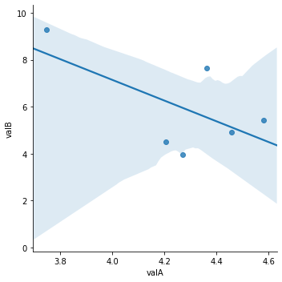

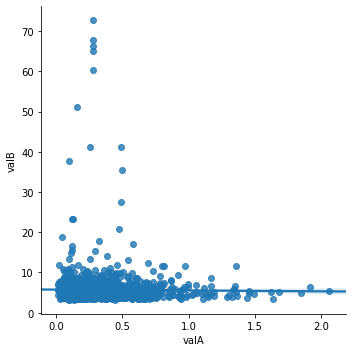

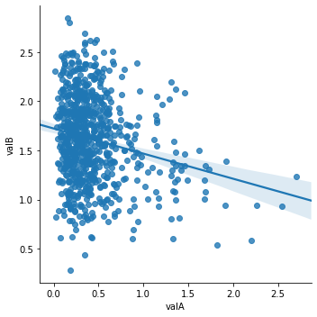

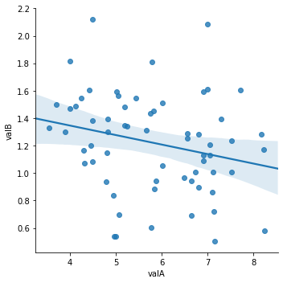

```python
import seaborn as sns
sns.lmplot(data=df[df.typeA=='cond1'][df.typeB=='cond1'],x='valA',y='valB')
sns.lmplot(data=df[df.typeA=='common'][df.typeB=='cond1'],x='valA',y='valB')
sns.lmplot(data=df[df.typeA=='common'][df.typeB=='common'],x='valA',y='valB')
sns.lmplot(data=df[df.typeA=='cond2'][df.typeB=='common'],x='valA',y='valB')
```

As expected, plots are definitely unconclusives..

# Making profiles plot

```python
! ls -alh $folder
```

```
total 34M
drwxr-xr-x 2 jeremie jeremie 4.0K Jan 28 22:14 .
drwxr-xr-x 5 jeremie jeremie 4.0K Jan 31 18:22 ..
-rw-r--r-- 1 jeremie jeremie  32K Feb  1 16:42 MV411_IRF2BP2_DMSO_FLAG_IRF2BP2_R1_vs_MV411_IRF2BP2_VHL_FLAG_IRF2BP2_R1_c3.0_common.bed
-rw-r--r-- 1 jeremie jeremie 2.2M Feb  1 16:42 MV411_IRF2BP2_DMSO_FLAG_IRF2BP2_R1_vs_MV411_IRF2BP2_VHL_FLAG_IRF2BP2_R1_c3.0_cond1.bed
-rw-r--r-- 1 jeremie jeremie   90 Feb  1 16:42 MV411_IRF2BP2_DMSO_FLAG_IRF2BP2_R1_vs_MV411_IRF2BP2_VHL_FLAG_IRF2BP2_R1_c3.0_cond2.bed
-rw-r--r-- 1 jeremie jeremie  89K Feb  1 16:49 MV411_IRF2BP2_DMSO_MED1_R1_vs_MV411_IRF2BP2_VHL_MED1_R1_c3.0_common.bed
-rw-r--r-- 1 jeremie jeremie 285K Feb  1 16:49 MV411_IRF2BP2_DMSO_MED1_R1_vs_MV411_IRF2BP2_VHL_MED1_R1_c3.0_cond1.bed
-rw-r--r-- 1 jeremie jeremie   90 Feb  1 16:49 MV411_IRF2BP2_DMSO_MED1_R1_vs_MV411_IRF2BP2_VHL_MED1_R1_c3.0_cond2.bed
-rw-r--r-- 1 jeremie jeremie 5.4M Feb  1 16:57 MV411_IRF2BP2_DMSO_MYB_R1_vs_MV411_IRF2BP2_VHL_MYB_R1_c3.0_common.bed
-rw-r--r-- 1 jeremie jeremie  466 Feb  1 16:57 MV411_IRF2BP2_DMSO_MYB_R1_vs_MV411_IRF2BP2_VHL_MYB_R1_c3.0_cond1.bed
-rw-r--r-- 1 jeremie jeremie 1.3M Feb  1 16:57 MV411_IRF2BP2_DMSO_MYB_R1_vs_MV411_IRF2BP2_VHL_MYB_R1_c3.0_cond2.bed
-rw-r--r-- 1 jeremie jeremie 4.2M Feb  1 17:05 MV411_IRF2BP2_DMSO_MYC_R1_vs_MV411_IRF2BP2_VHL_MYC_R1_c3.0_common.bed
-rw-r--r-- 1 jeremie jeremie  71K Feb  1 17:05 MV411_IRF2BP2_DMSO_MYC_R1_vs_MV411_IRF2BP2_VHL_MYC_R1_c3.0_cond1.bed
-rw-r--r-- 1 jeremie jeremie 727K Feb  1 17:05 MV411_IRF2BP2_DMSO_MYC_R1_vs_MV411_IRF2BP2_VHL_MYC_R1_c3.0_cond2.bed
-rw-r--r-- 1 jeremie jeremie 1.1M Feb  1 17:12 MV411_IRF2BP2_DMSO_POLII_S2_R1_vs_MV411_IRF2BP2_VHL_POLII_S2_R1_c3.0_common.bed
-rw-r--r-- 1 jeremie jeremie 602K Feb  1 17:12 MV411_IRF2BP2_DMSO_POLII_S2_R1_vs_MV411_IRF2BP2_VHL_POLII_S2_R1_c3.0_cond1.bed
-rw-r--r-- 1 jeremie jeremie 2.7K Feb  1 17:12 MV411_IRF2BP2_DMSO_POLII_S2_R1_vs_MV411_IRF2BP2_VHL_POLII_S2_R1_c3.0_cond2.bed
-rw-r--r-- 1 jeremie jeremie 2.7K Feb  1 17:20 MV411_IRF2BP2_DMSO_POLII_S5_R1_vs_MV411_IRF2BP2_VHL_POLII_S5_R1_c3.0_common.bed
-rw-r--r-- 1 jeremie jeremie   90 Feb  1 17:20 MV411_IRF2BP2_DMSO_POLII_S5_R1_vs_MV411_IRF2BP2_VHL_POLII_S5_R1_c3.0_cond1.bed
-rw-r--r-- 1 jeremie jeremie 2.5M Feb  1 17:20 MV411_IRF2BP2_DMSO_POLII_S5_R1_vs_MV411_IRF2BP2_VHL_POLII_S5_R1_c3.0_cond2.bed
-rw-r--r-- 1 jeremie jeremie 2.0M Feb  1 17:29 MV411_IRF2BP2_DMSO_POLII_total_R1_vs_MV411_IRF2BP2_VHL_POLII_total_R1_c3.0_common.bed
-rw-r--r-- 1 jeremie jeremie 1.6K Feb  1 17:29 MV411_IRF2BP2_DMSO_POLII_total_R1_vs_MV411_IRF2BP2_VHL_POLII_total_R1_c3.0_cond1.bed
-rw-r--r-- 1 jeremie jeremie 427K Feb  1 17:29 MV411_IRF2BP2_DMSO_POLII_total_R1_vs_MV411_IRF2BP2_VHL_POLII_total_R1_c3.0_cond2.bed
-rw-r--r-- 1 jeremie jeremie  12M Feb  1 17:38 MV411_IRF2BP2_DMSO_SPI1_R1_vs_MV411_IRF2BP2_VHL_SPI1_R1_c3.0_common.bed
-rw-r--r-- 1 jeremie jeremie 911K Feb  1 17:38 MV411_IRF2BP2_DMSO_SPI1_R1_vs_MV411_IRF2BP2_VHL_SPI1_R1_c3.0_cond1.bed
-rw-r--r-- 1 jeremie jeremie  852 Feb  1 17:38 MV411_IRF2BP2_DMSO_SPI1_R1_vs_MV411_IRF2BP2_VHL_SPI1_R1_c3.0_cond2.bed
```

```python
peaks = ! ls $folder
```

```python
bigwig = ! ls $bfolder
num = 8
```

```python
bigwig
```

[output not shown]

```python
bigwig=[(bfolder+bigwig[i],bfolder+bigwig[i+num]) for i in range(num)]
```

```python
bigwig
```

[output not shown]

```python
peaks = [p for p in helper.grouped([folder+p for p in peaks],3)]
```

```python
! mkdir temp
```

```python
cov = {}
fig = {}
for i,peak in enumerate(peaks):
    p = pd.read_csv(peak[1],sep='\t',skiprows=1,header=None,
            names=['chrom','start','end','name','foldchange']).sort_values(by='foldchange',ascending=False).iloc[:500]
    p2 =pd.read_csv(peak[0],sep='\t',skiprows=1,header=None,
            names=['chrom','start','end','name','foldchange']).iloc[:500]
    p = p.append(p2)
    p2 =pd.read_csv(peak[2],sep='\t',skiprows=1,header=None,
            names=['chrom','start','end','name','foldchange']).sort_values(by='foldchange',ascending=True).iloc[-500:]
    p = p.append(p2)

    cov.update(chip.computePeaksAt(p,bigwig[i], window=1000, numpeaks=1500, numthreads=8,
                   width=5, length=10, name='temp/peaksat'+str(i)+'.png', sort=False)[0])
```

```python
for k,i in cov.items():
    print(k, i.max())
```

[output not shown]

```python
pd.read_csv(peak[1],sep='\t')
```